# ¿Cuál es la mejor tarifa?

Trabajas como analista para el operador de telecomunicaciones Megaline. La empresa ofrece a sus clientes dos tarifas de prepago, Surf y Ultimate. El departamento comercial quiere saber cuál de las tarifas genera más ingresos para poder ajustar el presupuesto de publicidad.

Vas a realizar un análisis preliminar de las tarifas basado en una selección de clientes relativamente pequeña. Tendrás los datos de 500 clientes de Megaline: quiénes son los clientes, de dónde son, qué tarifa usan, así como la cantidad de llamadas que hicieron y los mensajes de texto que enviaron en 2018. Tu trabajo es analizar el comportamiento de los clientes y determinar qué tarifa de prepago genera más ingresos.

## Inicialización

```python
# Cargar todas las librerías
import pandas as pd
import numpy as np
from scipy import stats as st
import seaborn as sns
from math import factorial
from matplotlib import pyplot as plt
```

## Cargar datos

```python
# Carga los archivos de datos en diferentes DataFrames
plans = pd.read_csv('datasets/megaline_plans.csv')
users = pd.read_csv('datasets/megaline_users.csv')
internet = pd.read_csv('datasets/megaline_internet.csv')
messages = pd.read_csv('datasets/megaline_messages.csv')
calls = pd.read_csv('datasets/megaline_calls.csv')
```

## Preparar los datos

## Tarifas

```python
# Imprime la información general/resumida sobre el DataFrame de las tarifas
plans.info()
print(plans)
```

```
<class 'pandas.core.frame.DataFrame'>
RangeIndex: 2 entries, 0 to 1
Data columns (total 8 columns):
 #   Column                 Non-Null Count  Dtype
---  ------                 --------------  -----
 0   messages_included      2 non-null      int64
 1   mb_per_month_included  2 non-null      int64
 2   minutes_included       2 non-null      int64
 3   usd_monthly_pay        2 non-null      int64
 4   usd_per_gb             2 non-null      int64
 5   usd_per_message        2 non-null      float64
 6   usd_per_minute         2 non-null      float64
 7   plan_name              2 non-null      object
dtypes: float64(2), int64(5), object(1)
memory usage: 260.0+ bytes
   messages_included  mb_per_month_included  minutes_included  \
0                 50                  15360               500
1               1000                  30720              3000

   usd_monthly_pay  usd_per_gb  usd_per_message  usd_per_minute plan_name
0               20          10             0.03            0.03      surf
1               70           7             0.01            0.01  ultimate
```

```python
# Imprime una muestra de los datos para las tarifas
plans.sample()
```

|  | messages_included | mb_per_month_included | minutes_included | usd_monthly_pay | usd_per_gb | usd_per_message | usd_per_minute | plan_name |
| --- | --- | --- | --- | --- | --- | --- | --- | --- |
| 1 | 1000 | 30720 | 3000 | 70 | 7 | 0.01 | 0.01 | ultimate |

## Corregir datos

## Enriquecer los datos

```python
plans = plans.rename(columns={'plan_name' : 'plan', 'mb_per_month_included' : 'gb_per_month_included'})
plans['gb_per_month_included'] = np.floor(plans['gb_per_month_included']/1024)


print(plans)
```

```
   messages_included  gb_per_month_included  minutes_included  \
0                 50                   15.0               500
1               1000                   30.0              3000

   usd_monthly_pay  usd_per_gb  usd_per_message  usd_per_minute      plan
0               20          10             0.03            0.03      surf
1               70           7             0.01            0.01  ultimate
```

## Usuarios/as

```python
# Imprime la información general/resumida sobre el DataFrame de usuarios
users.info()
print(users)
```

```
<class 'pandas.core.frame.DataFrame'>
RangeIndex: 500 entries, 0 to 499
Data columns (total 8 columns):
 #   Column      Non-Null Count  Dtype
---  ------      --------------  -----
 0   user_id     500 non-null    int64
 1   first_name  500 non-null    object
 2   last_name   500 non-null    object
 3   age         500 non-null    int64
 4   city        500 non-null    object
 5   reg_date    500 non-null    object
 6   plan        500 non-null    object
 7   churn_date  34 non-null     object
dtypes: int64(2), object(6)
memory usage: 31.4+ KB
```

[output cut: 40 more lines]

```python
# Imprime una muestra de datos para usuarios
print(users.sample(10))
```

```
     user_id first_name  last_name  age  \
141     1141    Kirstie     Hodges   46
63      1063   Larhonda    Hartman   60
72      1072    Seymour     Spence   66
123     1123    Dierdre       Nash   66
167     1167   Rebbecca  Nicholson   47
87      1087     Lenard   Atkinson   45
336     1336      Vance   Bradshaw   34
253     1253     Sumiko     Dudley   28
172     1172     Weldon   Robinson   72
118     1118      Deane    Ramirez   28

                                                 city    reg_date      plan  \
141         New York-Newark-Jersey City, NY-NJ-PA MSA  2018-06-26      surf
63          New York-Newark-Jersey City, NY-NJ-PA MSA  2018-11-05  ultimate
```

[output cut: 20 more lines]

### Corregir los datos

Se convertira los datos de fechas en tipo datetime64 en las columnas `'reg_date'` y `'churn_date'`.

```python
users['reg_date'] = pd.to_datetime(users['reg_date'], format= '%Y-%m-%d')
users['churn_date'] = pd.to_datetime(users['churn_date'], format= '%Y-%m-%d')


users.info()
```

```
<class 'pandas.core.frame.DataFrame'>
RangeIndex: 500 entries, 0 to 499
Data columns (total 8 columns):
 #   Column      Non-Null Count  Dtype
---  ------      --------------  -----
 0   user_id     500 non-null    int64
 1   first_name  500 non-null    object
 2   last_name   500 non-null    object
 3   age         500 non-null    int64
 4   city        500 non-null    object
 5   reg_date    500 non-null    datetime64[ns]
 6   plan        500 non-null    object
 7   churn_date  34 non-null     datetime64[ns]
dtypes: datetime64[ns](2), int64(2), object(4)
memory usage: 31.4+ KB
```

### Enriquecer los datos

Presencia de espacios en blanco en la columna `'churn_date'` debido a que cuanto se adquirio el dataset seguian vigentes los planes, por lo que se creara una columna que indique el estatus del plan de cada usuario

```python
users['status'] = np.where(users['churn_date'].isna(), 'active', 'inactive')
```

## Llamadas

```python
# Imprime la información general/resumida sobre el DataFrame de las llamadas
calls.info()
print(calls)
```

```
<class 'pandas.core.frame.DataFrame'>
RangeIndex: 137735 entries, 0 to 137734
Data columns (total 4 columns):
 #   Column     Non-Null Count   Dtype
---  ------     --------------   -----
 0   id         137735 non-null  object
 1   user_id    137735 non-null  int64
 2   call_date  137735 non-null  object
 3   duration   137735 non-null  float64
dtypes: float64(1), int64(1), object(2)
memory usage: 4.2+ MB
              id  user_id   call_date  duration
0        1000_93     1000  2018-12-27      8.52
1       1000_145     1000  2018-12-27     13.66
2       1000_247     1000  2018-12-27     14.48
3       1000_309     1000  2018-12-28      5.76
4       1000_380     1000  2018-12-30      4.22
...          ...      ...         ...       ...
137730  1499_199     1499  2018-11-21      8.72
137731  1499_200     1499  2018-10-20     10.89
137732  1499_201     1499  2018-09-21      8.12
137733  1499_202     1499  2018-10-10      0.37
137734  1499_203     1499  2018-12-29     13.86

[137735 rows x 4 columns]
```

```python
# Imprime una muestra de datos para las llamadas
print(calls.sample(10))
```

```
              id  user_id   call_date  duration
93796    1335_24     1335  2018-07-12     18.42
29098   1110_149     1110  2018-12-16     10.07
35088   1132_456     1132  2018-09-08      4.05
25486   1098_161     1098  2018-11-04      5.80
13650    1058_66     1058  2018-11-12      3.25
105763  1373_243     1373  2018-11-30     15.83
73486   1261_242     1261  2018-12-14     10.02
90000   1326_651     1326  2018-09-15      8.74
31711    1120_36     1120  2018-05-04      9.72
32390   1122_228     1122  2018-10-16      0.00
```

### Corregir los datos

```python
calls['call_date'] = pd.to_datetime(calls['call_date'], format= '%Y-%m-%d')
calls['duration'] = np.ceil(calls['duration'])
calls = calls.rename(columns={'call_date' : 'date'})
print(calls)
```

```
              id  user_id       date  duration
0        1000_93     1000 2018-12-27       9.0
1       1000_145     1000 2018-12-27      14.0
2       1000_247     1000 2018-12-27      15.0
3       1000_309     1000 2018-12-28       6.0
4       1000_380     1000 2018-12-30       5.0
...          ...      ...        ...       ...
137730  1499_199     1499 2018-11-21       9.0
137731  1499_200     1499 2018-10-20      11.0
137732  1499_201     1499 2018-09-21       9.0
137733  1499_202     1499 2018-10-10       1.0
137734  1499_203     1499 2018-12-29      14.0

[137735 rows x 4 columns]
```

### Enriquecer los datos

## Mensajes

```python
# Imprime la información general/resumida sobre el DataFrame de los mensajes
messages.info()
print(messages)
```

```
<class 'pandas.core.frame.DataFrame'>
RangeIndex: 76051 entries, 0 to 76050
Data columns (total 3 columns):
 #   Column        Non-Null Count  Dtype
---  ------        --------------  -----
 0   id            76051 non-null  object
 1   user_id       76051 non-null  int64
 2   message_date  76051 non-null  object
dtypes: int64(1), object(2)
memory usage: 1.7+ MB
             id  user_id message_date
0      1000_125     1000   2018-12-27
1      1000_160     1000   2018-12-31
2      1000_223     1000   2018-12-31
3      1000_251     1000   2018-12-27
4      1000_255     1000   2018-12-26
...         ...      ...          ...
76046  1497_526     1497   2018-12-24
76047  1497_536     1497   2018-12-24
76048  1497_547     1497   2018-12-31
76049  1497_558     1497   2018-12-24
76050  1497_613     1497   2018-12-23

[76051 rows x 3 columns]
```

```python
# Imprime una muestra de datos para los mensajes
print(messages.sample(10))
```

```
             id  user_id message_date
13189  1088_131     1088   2018-06-24
12659  1082_228     1082   2018-12-25
46963  1320_207     1320   2018-06-06
53966   1343_47     1343   2018-11-06
48653  1326_190     1326   2018-07-31
56603  1357_301     1357   2018-09-19
1291   1011_254     1011   2018-09-23
17851  1115_737     1115   2018-12-01
55169  1347_206     1347   2018-08-06
47038  1320_282     1320   2018-08-08
```

### Corregir los datos

[Corrige los problemas obvios con los datos basándote en las observaciones iniciales.]

```python
messages['message_date'] = pd.to_datetime(messages['message_date'], format='%Y-%m-%d')
messages = messages.rename(columns={'message_date' : 'date'})
messages.info()
```

```
<class 'pandas.core.frame.DataFrame'>
RangeIndex: 76051 entries, 0 to 76050
Data columns (total 3 columns):
 #   Column   Non-Null Count  Dtype
---  ------   --------------  -----
 0   id       76051 non-null  object
 1   user_id  76051 non-null  int64
 2   date     76051 non-null  datetime64[ns]
dtypes: datetime64[ns](1), int64(1), object(1)
memory usage: 1.7+ MB
```

## Internet

```python
# Imprime la información general/resumida sobre el DataFrame de internet
internet.info()
print(internet)
```

```
<class 'pandas.core.frame.DataFrame'>
RangeIndex: 104825 entries, 0 to 104824
Data columns (total 4 columns):
 #   Column        Non-Null Count   Dtype
---  ------        --------------   -----
 0   id            104825 non-null  object
 1   user_id       104825 non-null  int64
 2   session_date  104825 non-null  object
 3   mb_used       104825 non-null  float64
dtypes: float64(1), int64(1), object(2)
memory usage: 3.2+ MB
              id  user_id session_date  mb_used
0        1000_13     1000   2018-12-29    89.86
1       1000_204     1000   2018-12-31     0.00
2       1000_379     1000   2018-12-28   660.40
3       1000_413     1000   2018-12-26   270.99
4       1000_442     1000   2018-12-27   880.22
...          ...      ...          ...      ...
104820  1499_215     1499   2018-10-20   218.06
104821  1499_216     1499   2018-12-30   304.72
104822  1499_217     1499   2018-09-22   292.75
104823  1499_218     1499   2018-12-07     0.00
104824  1499_219     1499   2018-12-24   758.31

[104825 rows x 4 columns]
```

```python
# Imprime una muestra de datos para el tráfico de internet
print(internet.sample(10))
```

```
             id  user_id session_date  mb_used
54720  1247_135     1247   2018-09-27   381.56
45404  1201_267     1201   2018-06-29   568.11
26371  1122_326     1122   2018-08-04   347.54
34721  1156_318     1156   2018-12-08   429.04
10357  1053_399     1053   2018-09-30    69.19
86914  1403_262     1403   2018-09-06   406.82
21991  1100_195     1100   2018-12-31   567.16
62762   1289_81     1289   2018-12-16   245.50
95167  1444_118     1444   2018-11-03   356.14
73562  1346_143     1346   2018-09-14   403.90
```

### Corregir los datos

```python
internet['session_date'] = pd.to_datetime(internet['session_date'], format='%Y-%m-%d')
internet = internet.rename(columns = {'session_date' : 'date'})
print(internet)
```

```
              id  user_id       date  mb_used
0        1000_13     1000 2018-12-29    89.86
1       1000_204     1000 2018-12-31     0.00
2       1000_379     1000 2018-12-28   660.40
3       1000_413     1000 2018-12-26   270.99
4       1000_442     1000 2018-12-27   880.22
...          ...      ...        ...      ...
104820  1499_215     1499 2018-10-20   218.06
104821  1499_216     1499 2018-12-30   304.72
104822  1499_217     1499 2018-09-22   292.75
104823  1499_218     1499 2018-12-07     0.00
104824  1499_219     1499 2018-12-24   758.31

[104825 rows x 4 columns]
```

### Enriquecer los datos

## Estudiar las condiciones de las tarifas

```python
# Imprime las condiciones de la tarifa y asegúrate de que te quedan claras
print(plans)
```

```
   messages_included  gb_per_month_included  minutes_included  \
0                 50                   15.0               500
1               1000                   30.0              3000

   usd_monthly_pay  usd_per_gb  usd_per_message  usd_per_minute      plan
0               20          10             0.03            0.03      surf
1               70           7             0.01            0.01  ultimate
```

## Agregar datos por usuario

```python
# Calcula el número de llamadas hechas por cada usuario al mes. Guarda el resultado.
monthly_calls = calls.groupby(['user_id', pd.Grouper(key='date', freq='ME')]).count().reset_index()
monthly_calls = monthly_calls.drop(columns = 'id').rename(columns = {'duration' : 'calls_quantity'})
print(monthly_calls)
```

```
      user_id       date  calls_quantity
0        1000 2018-12-31              16
1        1001 2018-08-31              27
2        1001 2018-09-30              49
3        1001 2018-10-31              65
4        1001 2018-11-30              64
...       ...        ...             ...
2253     1498 2018-12-31              39
2254     1499 2018-09-30              41
2255     1499 2018-10-31              53
2256     1499 2018-11-30              45
2257     1499 2018-12-31              65

[2258 rows x 3 columns]
```

```python
# Calcula la cantidad de minutos usados por cada usuario al mes. Guarda el resultado.
monthly_minutes_expended = calls.groupby(['user_id', pd.Grouper(key='date', freq='ME')])['duration'].sum().reset_index().rename(columns={'duration':'minutes_expend'})
print(monthly_minutes_expended)
```

```
      user_id       date  minutes_expend
0        1000 2018-12-31           124.0
1        1001 2018-08-31           182.0
2        1001 2018-09-30           315.0
3        1001 2018-10-31           393.0
4        1001 2018-11-30           426.0
...       ...        ...             ...
2253     1498 2018-12-31           339.0
2254     1499 2018-09-30           346.0
2255     1499 2018-10-31           385.0
2256     1499 2018-11-30           308.0
2257     1499 2018-12-31           496.0

[2258 rows x 3 columns]
```

```python
# Calcula el número de mensajes enviados por cada usuario al mes. Guarda el resultado.
monthly_messages = messages.groupby(['user_id', pd.Grouper(key='date', freq='ME')]).count().reset_index().rename(columns={'id' : 'messages_quantity'})
print(monthly_messages)
```

```
      user_id       date  messages_quantity
0        1000 2018-12-31                 11
1        1001 2018-08-31                 30
2        1001 2018-09-30                 44
3        1001 2018-10-31                 53
4        1001 2018-11-30                 36
...       ...        ...                ...
1801     1496 2018-09-30                 21
1802     1496 2018-10-31                 18
1803     1496 2018-11-30                 13
1804     1496 2018-12-31                 11
1805     1497 2018-12-31                 50

[1806 rows x 3 columns]
```

```python
### Calcula el volumen del tráfico de Internet usado por cada usuario al mes. Guarda el resultado.
monthly_internet_used = internet.groupby(['user_id', pd.Grouper(key='date', freq='ME')])['mb_used'].sum().reset_index()
monthly_internet_used['mb_used'] = (np.ceil(monthly_internet_used['mb_used']/1024))
monthly_internet_used = monthly_internet_used.rename(columns={'mb_used':'gb_used'})
print(monthly_internet_used)
```

```
      user_id       date  gb_used
0        1000 2018-12-31      2.0
1        1001 2018-08-31      7.0
2        1001 2018-09-30     14.0
3        1001 2018-10-31     22.0
4        1001 2018-11-30     19.0
...       ...        ...      ...
2272     1498 2018-12-31     23.0
2273     1499 2018-09-30     13.0
2274     1499 2018-10-31     20.0
2275     1499 2018-11-30     17.0
2276     1499 2018-12-31     22.0

[2277 rows x 3 columns]
```

[Junta los datos agregados en un DataFrame para que haya un registro que represente lo que consumió un usuario único en un mes determinado.]

```python
# Fusiona los datos de llamadas, minutos, mensajes e Internet con base en user_id y month
users_consume = monthly_calls.merge(monthly_minutes_expended)
users_consume = users_consume.merge(monthly_messages)
users_consume = users_consume.merge(monthly_internet_used)
print(users_consume)
```

```
      user_id       date  calls_quantity  minutes_expend  messages_quantity  \
0        1000 2018-12-31              16           124.0                 11
1        1001 2018-08-31              27           182.0                 30
2        1001 2018-09-30              49           315.0                 44
3        1001 2018-10-31              65           393.0                 53
4        1001 2018-11-30              64           426.0                 36
...       ...        ...             ...             ...                ...
1754     1496 2018-09-30              52           414.0                 21
1755     1496 2018-10-31              46           317.0                 18
1756     1496 2018-11-30              39           308.0                 13
1757     1496 2018-12-31              40           294.0                 11
1758     1497 2018-12-31              54           300.0                 50

      gb_used
0         2.0
1         7.0
2        14.0
3        22.0
4        19.0
...       ...
1754     17.0
1755     14.0
1756      9.0
1757     17.0
1758     11.0

[1759 rows x 6 columns]
```

```python
# Añade la información de la tarifa
users_consume = users_consume.merge(users[['user_id', 'plan']], on = 'user_id')
#print(users_consume)
print(plans)
users_consume = users_consume.merge(plans, on = 'plan')
```

```
   messages_included  gb_per_month_included  minutes_included  \
0                 50                   15.0               500
1               1000                   30.0              3000

   usd_monthly_pay  usd_per_gb  usd_per_message  usd_per_minute      plan
0               20          10             0.03            0.03      surf
1               70           7             0.01            0.01  ultimate
```

[Calcula los ingresos mensuales por usuario (resta el límite del paquete gratuito del número total de llamadas, mensajes de texto y datos; multiplica el resultado por el valor del plan de llamadas; añade la tarifa mensual en función del plan de llamadas). Nota: Dadas las condiciones del plan, ¡esto podría no ser tan trivial como un par de líneas! Así que no pasa nada si dedicas algo de tiempo a ello.]

```python
# Calcula el ingreso mensual para cada usuario
call_cost =  np.where(
    users_consume['minutes_expend'] > users_consume['minutes_included'],
    (users_consume['minutes_expend'] - users_consume['minutes_included']) * users_consume['usd_per_minute'], 0
)
message_cost = np.where(
    users_consume['messages_quantity'] > users_consume['messages_included'],
    (users_consume['messages_quantity']- users_consume['messages_included']) * users_consume['usd_per_message'], 0
)
internet_cost = np.where(
    users_consume['gb_used'] > users_consume['gb_per_month_included'],
    (users_consume['gb_used'] - users_consume['gb_per_month_included']) * users_consume['usd_per_gb'], 0
)

total_cost = call_cost + message_cost + internet_cost + users_consume['usd_monthly_pay']
users_consume['call_costs'] = call_cost
users_consume['message_costs'] = message_cost
users_consume['internet_costs'] = internet_cost
users_consume['total_costs'] = total_cost
print(users_consume)
users_consume.info()
```

```
      user_id       date  calls_quantity  minutes_expend  messages_quantity  \
0        1000 2018-12-31              16           124.0                 11
1        1001 2018-08-31              27           182.0                 30
2        1001 2018-09-30              49           315.0                 44
3        1001 2018-10-31              65           393.0                 53
4        1001 2018-11-30              64           426.0                 36
...       ...        ...             ...             ...                ...
1754     1496 2018-09-30              52           414.0                 21
1755     1496 2018-10-31              46           317.0                 18
1756     1496 2018-11-30              39           308.0                 13
1757     1496 2018-12-31              40           294.0                 11
1758     1497 2018-12-31              54           300.0                 50

      gb_used      plan  messages_included  gb_per_month_included  \
0         2.0  ultimate               1000                   30.0
```

[output cut: 63 more lines]

## Estudia el comportamiento de usuario

[Calcula algunas estadísticas descriptivas para los datos agregados y fusionados que nos sean útiles y que muestren un panorama general captado por los datos. Dibuja gráficos útiles para facilitar la comprensión. Dado que la tarea principal es comparar las tarifas y decidir cuál es más rentable, las estadísticas y gráficas deben calcularse por tarifa.]

[En los comentarios hallarás pistas relevantes para las llamadas, pero no las hay para los mensajes e Internet. Sin embargo, el principio del estudio estadístico que se aplica para ellos es el mismo que para las llamadas.]

### Llamadas

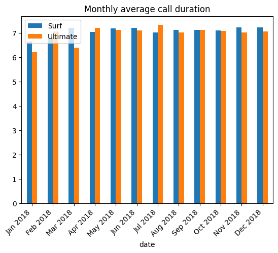

```python
# Compara la duración promedio de llamadas por cada plan y por cada mes. Traza un gráfico de barras para visualizarla.
def average_values_mothly_graph_bars(df_data, column_name, graph_title ):
    monthly_data = df_data.drop(columns='id')
    monthly_data = monthly_data.groupby(['user_id', pd.Grouper(key='date', freq='ME')]).mean().reset_index()
    monthly_data = monthly_data.merge(users[['user_id', 'plan']])


    data_by_plan = monthly_data.pivot_table(
        index='date',
        columns='plan',
        values= column_name
        )
    data_by_plan = data_by_plan.fillna(0)
    month_labels = [date.strftime('%b %Y') for date in data_by_plan.index]
    data_by_plan_plot = data_by_plan.plot(kind='bar', title= graph_title)
    tick_locations = data_by_plan_plot.get_xticks()
    data_by_plan_plot.set_xticks(tick_locations),
    data_by_plan_plot.set_xticklabels(month_labels, rotation=45, ha='right')
    plt.legend(['Surf', 'Ultimate'])
    plt.show()
    return

average_values_mothly_graph_bars(calls, 'duration', 'Monthly average call duration' )
```

```
      user_id       date  minutes_expend
0        1000 2018-12-31           124.0
1        1001 2018-08-31           182.0
2        1001 2018-09-30           315.0
3        1001 2018-10-31           393.0
4        1001 2018-11-30           426.0
...       ...        ...             ...
1754     1496 2018-09-30           414.0
1755     1496 2018-10-31           317.0
1756     1496 2018-11-30           308.0
1757     1496 2018-12-31           294.0
1758     1497 2018-12-31           300.0

[1759 rows x 3 columns]
```

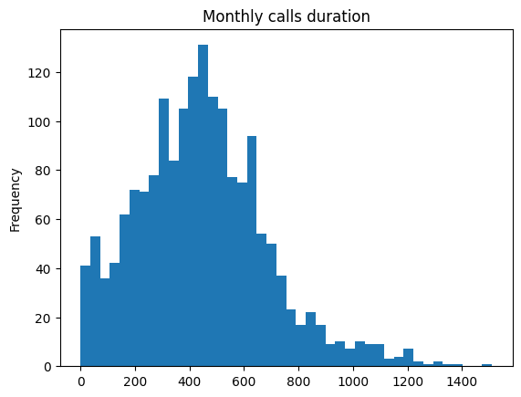

```python
def all_plans_histogram(monthly_df, column_name, hist_title):
    monthly_variable = monthly_df.groupby(['user_id', pd.Grouper(key='date', freq='ME')])[column_name].sum().reset_index()
    print(monthly_variable)
    bin_number = int(np.round(np.sqrt(monthly_variable.index.max() + 1)))
    monthly_variable[column_name].plot(
        kind= 'hist', bins = bin_number, title = hist_title
        )
    plt.show()
    return


all_plans_histogram(users_consume, 'minutes_expend', 'Monthly calls duration')
```

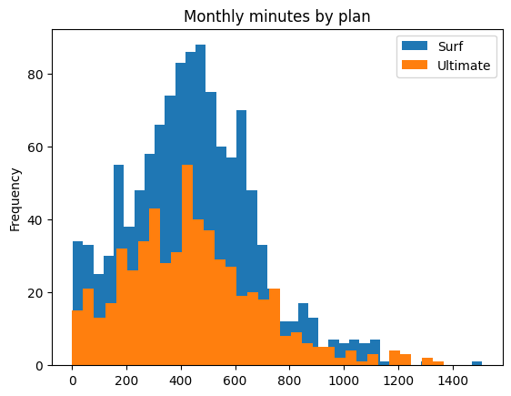

```python
# Compara el número de minutos mensuales que necesitan los usuarios de cada plan. Traza un histograma.
def monthly_consume_by_plan_hist(monthly_df, column_name, graph_title, bin_number_surf, bin_number_ultimate):
    df_plan_surf = monthly_df[monthly_df['plan'] == 'surf']
    df_plan_ultimate = monthly_df[monthly_df['plan'] == 'ultimate']


    df_plan_surf[column_name].plot(kind= 'hist', bins =bin_number_surf, title= graph_title)
    df_plan_ultimate[column_name].plot(kind= 'hist', bins =bin_number_ultimate)
    plt.legend(['Surf', 'Ultimate'])
    plt.show()

monthly_consume_by_plan_hist(users_consume, 'minutes_expend', 'Monthly minutes by plan', 40, 34)
```

[Calcula la media y la variable de la duración de las llamadas para averiguar si los usuarios de los distintos planes se comportan de forma diferente al realizar sus llamadas.]

```python
# Calcula la media y la varianza de la duración mensual de llamadas.
def monthly_consume_mean_variance_and_std(monthly_df, column_name, explicative_sentence, plan_1, plan_2, explicative_sentence_2, variable):
    df_plan_surf = monthly_df[monthly_df['plan'] == 'surf']
    df_plan_ultimate = monthly_df[monthly_df['plan'] == 'ultimate']
    print(explicative_sentence, plan_1, df_plan_surf[column_name].mean().round(2), variable,'con una varianza de', df_plan_surf[column_name].var().round(2), explicative_sentence_2, df_plan_surf[column_name].std().round(2))
    print(explicative_sentence, plan_2,df_plan_ultimate[column_name].mean().round(2), variable,'con una varianza de', df_plan_ultimate[column_name].var().round(2), explicative_sentence_2, df_plan_ultimate[column_name].std().round(2))
    return

monthly_consume_mean_variance_and_std(users_consume, 'minutes_expend', 'La cantidad promedio de minutos gastados por los usuarios del plan', 'surf es:', 'ultimate es:', 'y una desviación estándar es:', 'minutos,')
```

```
La cantidad promedio de minutos gastados por los usuarios del plan surf es: 445.78 minutos, con una varianza de 55321.41 y una desviación estándar es: 235.21
La cantidad promedio de minutos gastados por los usuarios del plan ultimate es: 442.51 minutos, con una varianza de 62288.4 y una desviación estándar es: 249.58
```

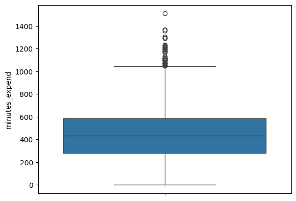

```python
# Traza un diagrama de caja para visualizar la distribución de la duración mensual de llamadas
sns.boxplot(users_consume['minutes_expend'])
```

Conclusion

La duración de las llamadas realizadas los usuarios de ambos planes son bastante similares, dado que la forma del histograma y el grafico de barras no detallan una diferencia tan grande, mientras que su promedio y desviación estándar son cercanas; sin embargo es posible ver que existen usuarios que suelen consumir una mayor cantidad de minutos, como se observa en grafica de caja con la presencia de valores atipicos, y la alta varianza-desviacion estandar que manejan ambos grupos

### Mensajes

```
plan             surf   ultimate
date
2018-01-31  21.000000  20.666667
2018-02-28  21.600000  27.800000
2018-03-31  21.937500  34.714286
2018-04-30  24.685714  28.937500
2018-05-31  33.547170  44.333333
2018-06-30  32.742857  37.135135
2018-07-31  34.786517  41.212766
2018-08-31  37.302521  47.929825
2018-09-30  38.585034  45.901408
2018-10-31  41.475138  47.488636
2018-11-30  40.087156  47.656863
2018-12-31  47.686992  53.744000
```

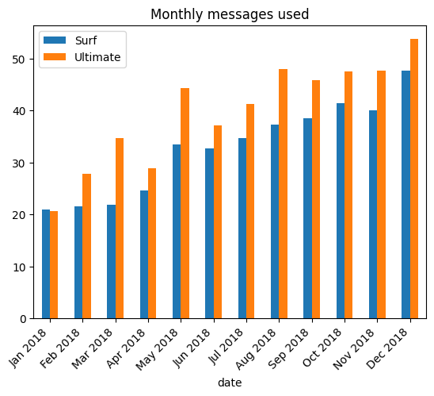

```python
def average_values_mothly_graph_bars(df_data, column_name, graph_title ):
    monthly_data = df_data[['user_id' ,'date' ,column_name]]
    monthly_data = monthly_data.groupby(['user_id', pd.Grouper(key='date', freq='ME')]).mean().reset_index()
    monthly_data = monthly_data.merge(users[['user_id', 'plan']])


    data_by_plan = monthly_data.pivot_table(
        index='date',
        columns='plan',
        values= column_name
        )
    data_by_plan = data_by_plan.fillna(0)
    month_labels = [date.strftime('%b %Y') for date in data_by_plan.index]
    print(data_by_plan)
    data_by_plan_plot = data_by_plan.plot(kind='bar', title= graph_title)
    tick_locations = data_by_plan_plot.get_xticks()
    data_by_plan_plot.set_xticks(tick_locations),
    data_by_plan_plot.set_xticklabels(month_labels, rotation=45, ha='right')
    plt.legend(['Surf', 'Ultimate'])
    plt.show()

average_values_mothly_graph_bars(users_consume, 'messages_quantity', 'Monthly messages used')
```

```
      user_id       date  messages_quantity
0        1000 2018-12-31                 11
1        1001 2018-08-31                 30
2        1001 2018-09-30                 44
3        1001 2018-10-31                 53
4        1001 2018-11-30                 36
...       ...        ...                ...
1754     1496 2018-09-30                 21
1755     1496 2018-10-31                 18
1756     1496 2018-11-30                 13
1757     1496 2018-12-31                 11
1758     1497 2018-12-31                 50

[1759 rows x 3 columns]
```

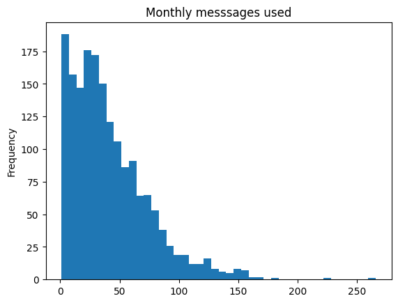

```python
all_plans_histogram(users_consume, 'messages_quantity', 'Monthly messsages used')
```

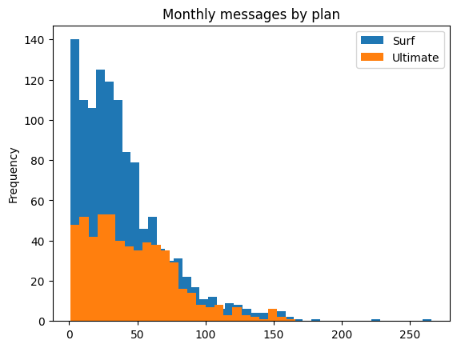

```python
monthly_consume_by_plan_hist(users_consume, 'messages_quantity', 'Monthly messages by plan', 42, 25)
```

```python
monthly_consume_mean_variance_and_std(users_consume, 'messages_quantity', 'La cantidad de mensajes usados por usuarios del plan', 'surf es:', 'ultimate es:', 'y una desviación estándar es:', 'mensajes,')
```

```
La cantidad de mensajes usados por usuarios del plan surf es: 39.49 mensajes, con una varianza de 1044.22 y una desviación estándar es: 32.31
La cantidad de mensajes usados por usuarios del plan ultimate es: 46.46 mensajes, con una varianza de 1084.39 y una desviación estándar es: 32.93
```

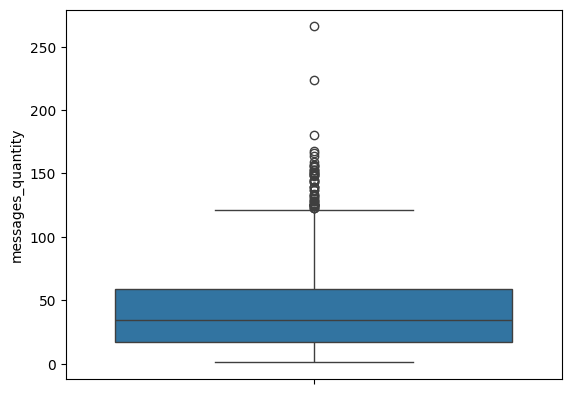

```python
sns.boxplot(users_consume['messages_quantity'])
```

Mensajes conclusiones

Se observa una tendencia de un aumento en la cantidad de mensajes enviados durante el año en ambos planes, en ambos planes, es posible ver que, en promedio, hay una ligera diferencia de ~7 mensajes a favor de los usuarios `utimate`, altamente dispersa, como se observa la desviación estándar y el diagrama de caja y bigotes.

### Internet

```
plan             surf   ultimate
date
2018-01-31   8.000000   7.333333
2018-02-28   9.400000  17.400000
2018-03-31  12.625000  23.857143
2018-04-30  12.085714  14.500000
2018-05-31  15.056604  17.238095
2018-06-30  15.771429  15.513514
2018-07-31  16.808989  16.638298
2018-08-31  17.252101  18.000000
2018-09-30  16.612245  16.464789
2018-10-31  17.524862  17.636364
2018-11-30  16.389908  17.401961
2018-12-31  18.089431  18.352000
```

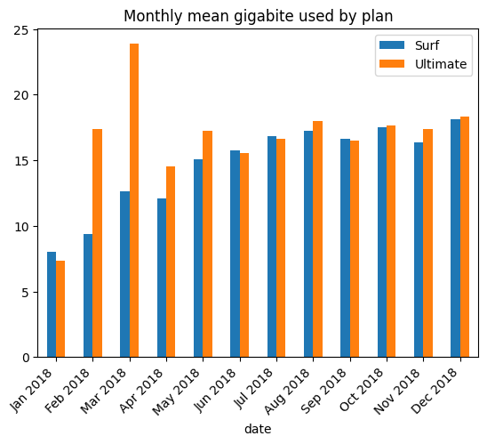

```python
# Compara la cantidad de tráfico de Internet consumido por usuarios por plan
average_values_mothly_graph_bars(users_consume, 'gb_used', 'Monthly mean gigabite used by plan')
```

```
      user_id       date  gb_used
0        1000 2018-12-31      2.0
1        1001 2018-08-31      7.0
2        1001 2018-09-30     14.0
3        1001 2018-10-31     22.0
4        1001 2018-11-30     19.0
...       ...        ...      ...
1754     1496 2018-09-30     17.0
1755     1496 2018-10-31     14.0
1756     1496 2018-11-30      9.0
1757     1496 2018-12-31     17.0
1758     1497 2018-12-31     11.0

[1759 rows x 3 columns]
```

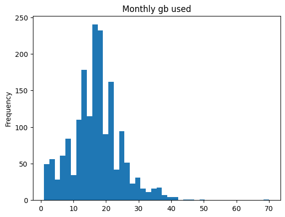

```python
all_plans_histogram(users_consume, 'gb_used', 'Monthly gb used')
```

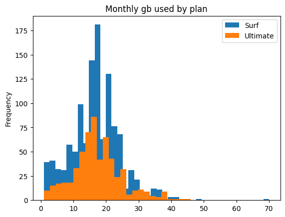

```python
monthly_consume_by_plan_hist(users_consume, 'gb_used', 'Monthly gb used by plan', 40, 25)
```

```python
monthly_consume_mean_variance_and_std(users_consume, 'gb_used', 'La cantidad de gigabites usados por usuarios del plan', 'surf es:', 'ultimate es:', 'y una desviación estándar es:', 'gb,')
```

```
La cantidad de gigabites usados por usuarios del plan surf es: 16.75 gb, con una varianza de 57.01 y una desviación estándar es: 7.55
La cantidad de gigabites usados por usuarios del plan ultimate es: 17.34 gb, con una varianza de 56.17 y una desviación estándar es: 7.49
```

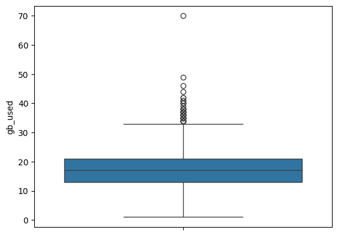

```python
sns.boxplot(users_consume['gb_used'])
```

El consumo de internet es similar por parte de los usuarios de ambos planes, como se observa en el histograma y en los promedios de dichos grupos, con respecto a la dispersión, es elevada, evidenciada por el digrama de caja y bigote, y la desviacion estándar, pero ambos se comportan de la misma manera.

## Ingreso

```
plan             surf   ultimate
date
2018-01-31  20.000000  70.000000
2018-02-28  23.914000  70.000000
2018-03-31  38.540625  78.000000
2018-04-30  40.591429  73.062500
2018-05-31  50.857170  71.000000
2018-06-30  52.081000  72.081081
2018-07-31  61.806404  72.382979
2018-08-31  64.383109  72.456140
2018-09-30  57.196871  71.380282
2018-10-31  65.368343  72.147727
2018-11-30  57.116606  72.127451
2018-12-31  68.777561  72.744000
```

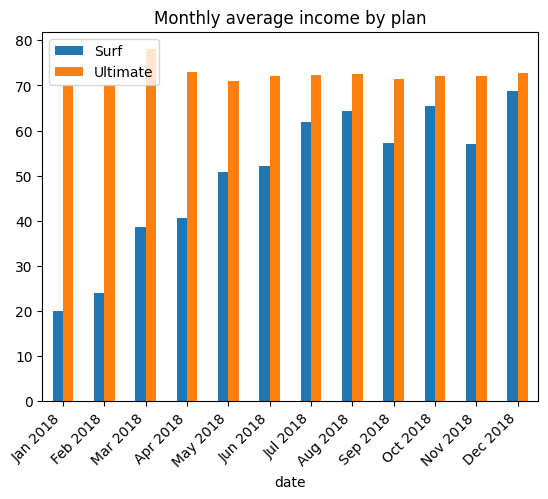

```python
average_values_mothly_graph_bars(users_consume, 'total_costs', 'Monthly average income by plan')
```

```
      user_id       date  total_costs
0        1000 2018-12-31        70.00
1        1001 2018-08-31        20.00
2        1001 2018-09-30        20.00
3        1001 2018-10-31        90.09
4        1001 2018-11-30        60.00
...       ...        ...          ...
1754     1496 2018-09-30        40.00
1755     1496 2018-10-31        20.00
1756     1496 2018-11-30        20.00
1757     1496 2018-12-31        40.00
1758     1497 2018-12-31        70.00

[1759 rows x 3 columns]
```

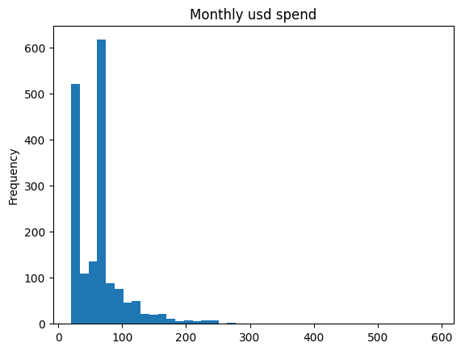

```python
all_plans_histogram(users_consume, 'total_costs', 'Monthly usd spend')
```

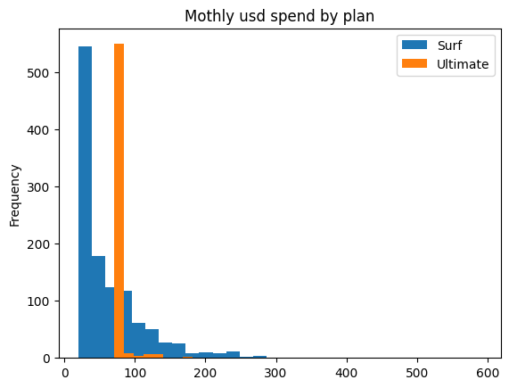

```python
monthly_consume_by_plan_hist(users_consume, 'total_costs', 'Mothly usd spend by plan', 30, 8)
```

```python
monthly_consume_mean_variance_and_std(users_consume, 'total_costs', 'Cantidad de dolares gastados por usuarios del plan','surf es:', 'ultimate es:', 'y una desviación estándar es:', 'dolares, ')
median_surf = users_consume[users_consume['plan'] == 'surf']
median_ultimate = users_consume[users_consume['plan'] == 'ultimate']
```

```
Cantidad de dolares gastados por usuarios del plan surf es: 60.42 dolares,  con una varianza de 2872.5 y una desviación estándar es: 53.6
Cantidad de dolares gastados por usuarios del plan ultimate es: 72.25 dolares,  con una varianza de 121.76 y una desviación estándar es: 11.03
```

```
plan            surf  ultimate
date
2018-01-31  0.000000       0.0
2018-02-28  1.866000       0.0
2018-03-31  1.016250       0.0
2018-04-30  1.374000       0.0
2018-05-31  2.184906       0.0
2018-06-30  1.623857       0.0
2018-07-31  2.315730       0.0
2018-08-31  1.807815       0.0
2018-09-30  1.533673       0.0
2018-10-31  1.919834       0.0
2018-11-30  1.910092       0.0
2018-12-31  2.777805       0.0
```

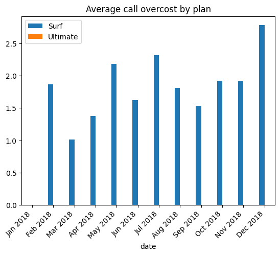

```
plan            surf  ultimate
date
2018-01-31  0.000000       0.0
2018-02-28  0.048000       0.0
2018-03-31  0.024375       0.0
2018-04-30  0.074571       0.0
2018-05-31  0.181698       0.0
2018-06-30  0.171429       0.0
2018-07-31  0.164831       0.0
2018-08-31  0.222353       0.0
2018-09-30  0.221020       0.0
2018-10-31  0.299337       0.0
2018-11-30  0.252385       0.0
2018-12-31  0.390000       0.0
```

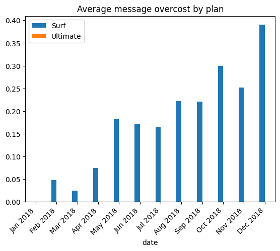

```
plan             surf  ultimate
date
2018-01-31   0.000000  0.000000
2018-02-28   2.000000  0.000000
2018-03-31  17.500000  8.000000
2018-04-30  19.142857  3.062500
2018-05-31  28.490566  1.000000
2018-06-30  30.285714  2.081081
2018-07-31  39.325843  2.382979
2018-08-31  42.352941  2.456140
2018-09-30  35.442177  1.380282
2018-10-31  43.149171  2.147727
2018-11-30  34.954128  2.127451
2018-12-31  45.609756  2.744000
```

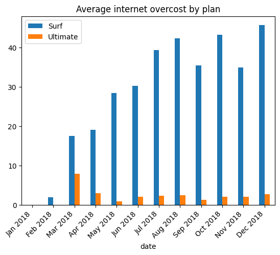

```python
average_values_mothly_graph_bars(users_consume, 'call_costs', 'Average call overcost by plan')
average_values_mothly_graph_bars(users_consume,'message_costs', 'Average message overcost by plan')
average_values_mothly_graph_bars(users_consume, 'internet_costs', 'Average internet overcost by plan')
```

```python
total_users_surf = users[users['plan'] == 'surf']
total_users_ultimate = users[users['plan'] == 'ultimate']

df_active_users = users[users['status'] == 'active']
df_active_users = df_active_users[['user_id', 'plan']]

df_active_users_surf = df_active_users[df_active_users['plan'] == 'surf']
df_active_users_ultimate = df_active_users[df_active_users['plan'] == 'ultimate']

proportion_of_active_users_surf = (df_active_users_surf['user_id'].count() / total_users_surf['user_id'].count())*100
proportion_of_active_users_ultimate = (df_active_users_ultimate['user_id'].count()/total_users_ultimate['user_id'].count() )*100


print('La cantidad de usuarios activos del plan surf es:',df_active_users_surf['plan'].count(),',mientras que, el numero de usuarios activos en el plan Ultimate es:',df_active_users_ultimate['plan'].count())
print('El porcentaje de los usuarios Surf activos es de:',proportion_of_active_users_surf.round(2),'%')
print('El porcentaje de los usuarios Ultimate activos es de:',proportion_of_active_users_ultimate.round(2),'%')
```

```
La cantidad de usuarios activos del plan surf es: 316 ,mientras que, el numero de usuarios activos en el plan Ultimate es: 150
El porcentaje de los usuarios Surf activos es de: 93.22 %
El porcentaje de los usuarios Ultimate activos es de: 93.17 %
```

## Diferencias por plan

Se requiere saber cual es el plan que permite la mejor captacion de ingresos en funcion al consumo memnsual por parte de los usuarios.

### Hipótesis nula

Los ingresos aportados por los usuarios del plan `surf` no son menores a los usuarios del plan `ultimate`.

### Hipotesis alterna

El promedio de los ingresos procedentes de los usuarios del plan `surf` es menor a los ingresos promedio de los provistos por los usuarios del plan `ultimate`.

```python
# Prueba las hipótesis
mensual_cost_surf = users_consume[users_consume['plan'] == 'surf']
mensual_cost_ultimate =  users_consume[users_consume['plan'] == 'ultimate']
mensual_cost_surf = mensual_cost_surf['total_costs']
mensual_cost_ultimate = mensual_cost_ultimate['total_costs']

# Se utiliza el valor 0.01 debido a que la diferencia nos permite ser rigurosos con el análisis, y obtener mas robustez en la diferencia de medias
alpha = 0.01

surf_vs_ultimate = st.ttest_ind(mensual_cost_surf, mensual_cost_ultimate, equal_var=False)

print('El promedio de los ingresos generados por los usuarios del plan Surf fue:',mensual_cost_surf.mean().round(2),'dolares' )
print('El promedio de los ingresos generados por los usuarios del plan Surf fue:',mensual_cost_ultimate.mean().round(2),'dolares' )

if (surf_vs_ultimate.pvalue/2 < alpha) and (mensual_cost_surf.mean() < mensual_cost_ultimate.mean()):
    print('Rechazamos la hipotesis nula y aceptamos la alterna')

else:
    print('No podemos rechazar la hipotesis nula')
```

[output not shown]

## Diferencias en ingresos por regiones

Se quiere saber especificamente si la region de NY-NJ genera mayor ingresos que las otras regiones en promedio

### Hipótesis nula

Los ingresos promedio generados por los usuarios de la region de NY-NJ no son significativamente mayores a los generados en las demas regiones.

### Hipotesis alterna

Los ingresos promedio de los usuarios de la región NY-NJ son mayores a los ingresos de las otras regiones.

```python
# Prueba las hipótesis

users_location = users[['user_id', 'city']]
users_consume_location = users_consume.merge(users_location, on='user_id')
```

```python
users_consume_NY_NJ = users_consume_location[users_consume_location['city'] == 'New York-Newark-Jersey City, NY-NJ-PA MSA']
users_consume_NY_NJ = users_consume_NY_NJ['total_costs']
users_consume_other_region = users_consume_location[users_consume_location['city'] != 'New York-Newark-Jersey City, NY-NJ-PA MSA']
users_consume_other_region = users_consume_other_region['total_costs']
```

```python
NY_NJ_vs_others = st.ttest_ind(users_consume_NY_NJ, users_consume_other_region, equal_var=True)

print('El promedio de los ingresos generados por los usuarios de la region NY-NJ fue:', users_consume_NY_NJ.mean().round(2), 'dolares')
print('El promedio de los ingresos generados por los usuarios de las otras regiones fue:',users_consume_other_region.mean().round(2),'dolares')

if (NY_NJ_vs_others.pvalue/2 < alpha) and (users_consume_NY_NJ.mean() > users_consume_other_region.mean()):
    print('La hipotesis nula se rechaza')
else:
    print('Se acepta la hipotesis nula')
```

```
El promedio de los ingresos generados por los usuarios de la region NY-NJ fue: 58.02 dolares
El promedio de los ingresos generados por los usuarios de las otras regiones fue: 65.5 dolares
Se acepta la hipotesis nula
```

## Conclusión general

Asi que con todo lo anterior dicho, la publicidad deberia ir en el orden de incrementar la cantidad de usuarios `Ultimate`, ya sea de que mejoren la suscripción los usuarios Surf o que se suscriban al plan de manera inicial.

Otra acción que podría ser recomendable, es la aplicación de llamadas y mensajes ilimitados para mejorar la experiencia del usuario, pues esta no impacta directamente en el ingreso de ambos planes, siendo inexistente en el plan `Ultimate`.

Tambien puede ser admisible la creacion de otro plan intermedio de $40 y que contenga caracteristicas intermedias entre `ultimate` y `surf` con el fin de que sea mas atractivo que el `surf` y exista una mayor recoleccion base con la tarifa mensual y no solo por los incrementos circustanciales por parte del usuario.

Con respecto a que si la region de `NY-NJ tiene` un mayor ingreso promedio con respecto a las demas regiones, no lo tiene, al menos de manera significativa, pues la diferencia entre ambos fue de `~7 dolares` en promedio.